# Potential Diagrams

This [vignette](http://chnosz.net/canprot/doc/index.html) from the R package canprot demonstrates the calculation of potential diagrams for a group of datasets and generation of a merged diagram. Specifically, the potential diagrams show the weighted rank difference of chemical affinities between up- and down-expressed proteins in each dataset. Groups of datasets are considered that have similar compositional features, i.e. changes in *Z*<sub>C</sub> and *n*̅<sub>H<sub>2</sub>O</sub>.

First, load the `canprot` package and data.

```r
library(canprot)
```

Here we make plots for datasets for pancreatic cancer having a mean difference of *n*̅<sub>H<sub>2</sub>O</sub> that is > 0.01 and a small *Z*<sub>C</sub>, as judged by the *p*-value and CLES. Red and blue correspond to greater potential for formation of the up- and down-expressed proteins, respectively; the line of equipotential is shown in white:

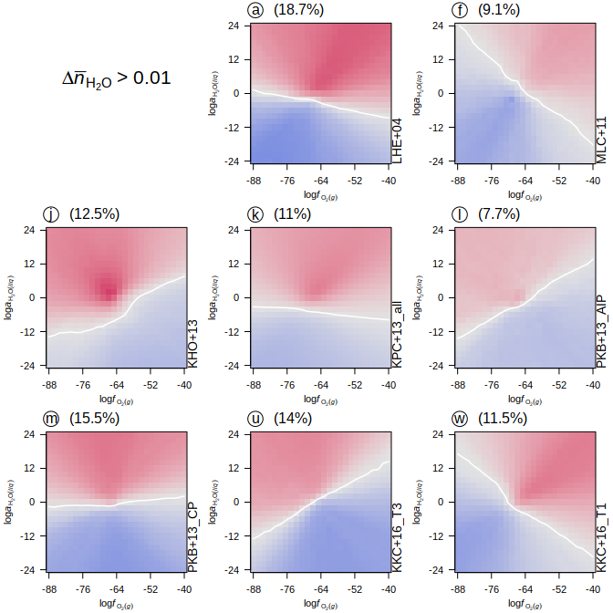

```r
gpresult <- groupplots("pancreatic_H2O_up", res = 25)
```

Now let’s make a merged diagram. The red-white-blue shading is computed from the mean of the previous diagrams. The black lines show the median and quartiles for the *y*-positions of the equipotential lines in the previous diagrams.

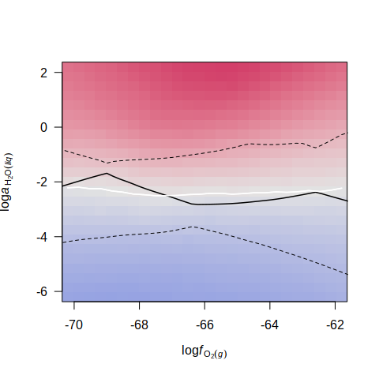

```r
mergedplot(gpresult, res = 25)
```

Higher-resolution versions of these plots have been published in Figure S3 and Figure 3 of Dick, 2017 (Chemical composition and the potential for proteomic transformation in cancer, hypoxia, and hyperosmotic stress. [*PeerJ* 5:e3421](https://doi.org/10.7717/peerj.3421)).